# Temporal network analysis

2024-03-12

This page follows analyses and recreates some plots from [Schulz J et al. (2017) PLOS ONE 12(6): e0179915](https://doi.org/10.1371/journal.pone.0179915).

# Basic network summary

## Network size

**Overall network size:** 500 holdings active over the observed time period

| month | holdings active (n) | holdings active (prop.) |
| --- | --- | --- |
| Jan 2019 | 419 | 0.838 |
| Feb 2019 | 395 | 0.790 |
| Mar 2019 | 401 | 0.802 |
| Apr 2019 | 411 | 0.822 |
| May 2019 | 412 | 0.824 |
| Jun 2019 | 418 | 0.836 |
| Jul 2019 | 404 | 0.808 |
| Aug 2019 | 409 | 0.818 |
| Sep 2019 | 402 | 0.804 |
| Oct 2019 | 412 | 0.824 |
| Nov 2019 | 419 | 0.838 |
| Dec 2019 | 417 | 0.834 |

### Holdings active (n)

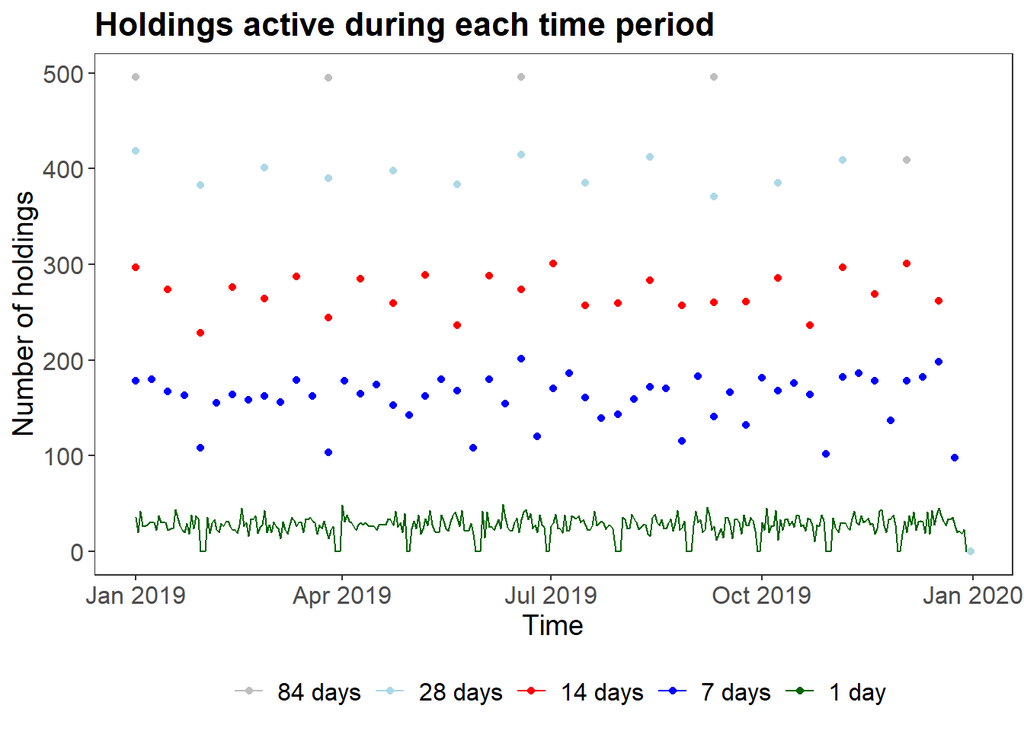

### Holdings active (prop)

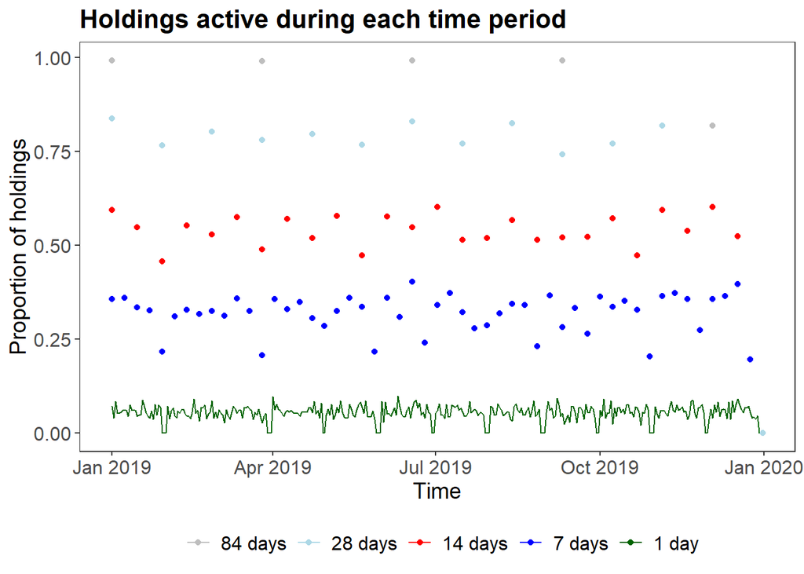

## Movements and edges

**Overall number of movements:** 5000 movements over the observed time period  
**Overall number of edges:** 4953 different links between holdings over the observed time period  
**Overall edge density:** 0.02 of all possible links between holdings are observed over the observed time period

| month | movements (n) | movements (prop.) | edges (n) | edges (prop.) | edge density (prop.) |
| --- | --- | --- | --- | --- | --- |
| Jan 2019 | 423 | 0.085 | 423 | 0.085 | 0.002 |
| Feb 2019 | 401 | 0.080 | 401 | 0.081 | 0.002 |
| Mar 2019 | 380 | 0.076 | 380 | 0.077 | 0.002 |
| Apr 2019 | 430 | 0.086 | 430 | 0.087 | 0.002 |
| May 2019 | 408 | 0.082 | 408 | 0.082 | 0.002 |
| Jun 2019 | 437 | 0.087 | 437 | 0.088 | 0.002 |
| Jul 2019 | 419 | 0.084 | 419 | 0.085 | 0.002 |
| Aug 2019 | 416 | 0.083 | 416 | 0.084 | 0.002 |
| Sep 2019 | 404 | 0.081 | 403 | 0.081 | 0.002 |
| Oct 2019 | 417 | 0.083 | 417 | 0.084 | 0.002 |
| Nov 2019 | 435 | 0.087 | 435 | 0.088 | 0.002 |
| Dec 2019 | 430 | 0.086 | 430 | 0.087 | 0.002 |

### Movements

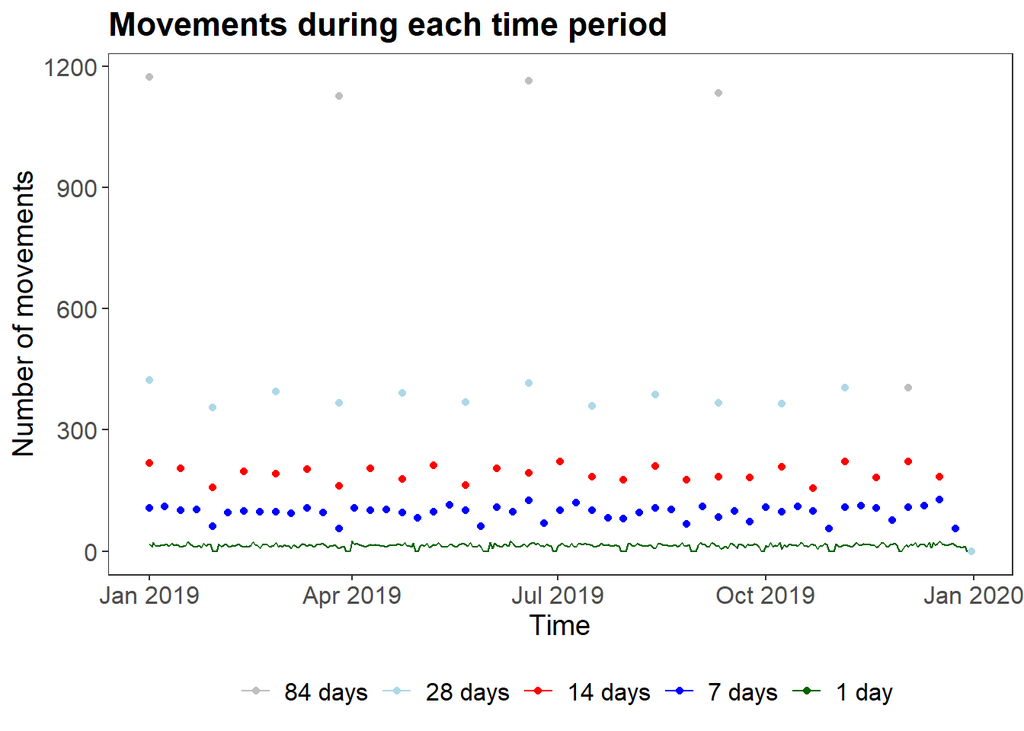

### Movements (prop.)

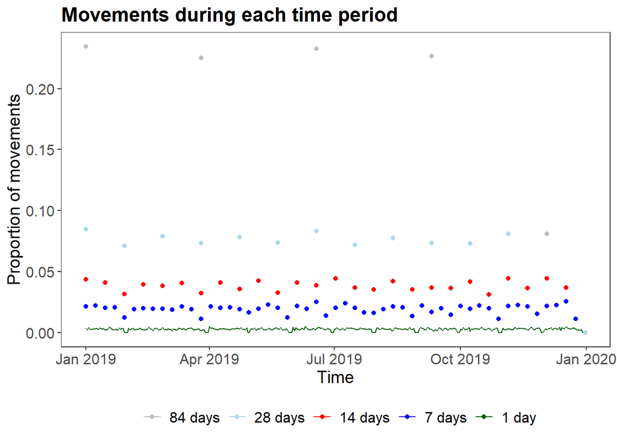

### Edges

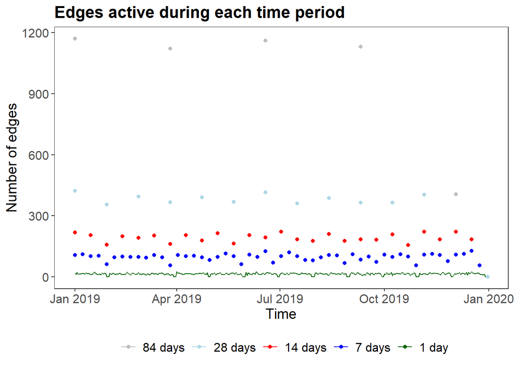

### Edges (prop.)

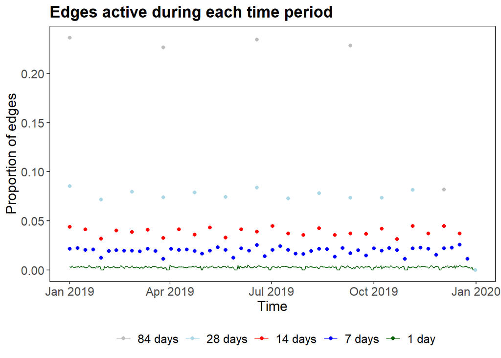

### Density

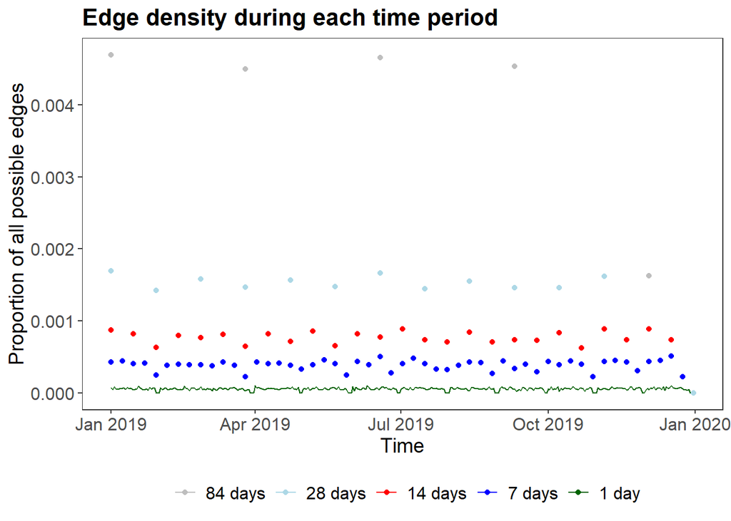

## Movement weights (batch sizes)

| month | min | Q1 | median | mean | Q3 | max |
| --- | --- | --- | --- | --- | --- | --- |
| Jan 2019 | 30 | 66.00 | 109.0 | 108.986 | 148.50 | 189 |
| Feb 2019 | 30 | 68.00 | 106.0 | 106.474 | 147.00 | 189 |
| Mar 2019 | 30 | 71.00 | 113.0 | 111.774 | 150.00 | 189 |
| Apr 2019 | 30 | 66.00 | 100.0 | 103.940 | 141.75 | 189 |
| May 2019 | 30 | 68.00 | 106.0 | 106.978 | 143.00 | 189 |
| Jun 2019 | 30 | 73.00 | 116.0 | 111.881 | 149.00 | 189 |
| Jul 2019 | 30 | 69.00 | 104.0 | 106.210 | 143.00 | 189 |
| Aug 2019 | 30 | 67.00 | 109.5 | 108.731 | 150.00 | 187 |
| Sep 2019 | 30 | 76.00 | 115.0 | 113.460 | 152.75 | 189 |
| Oct 2019 | 30 | 72.00 | 112.0 | 111.518 | 152.00 | 189 |
| Nov 2019 | 30 | 70.50 | 107.0 | 110.011 | 151.50 | 189 |
| Dec 2019 | 30 | 73.25 | 113.5 | 111.293 | 151.00 | 189 |

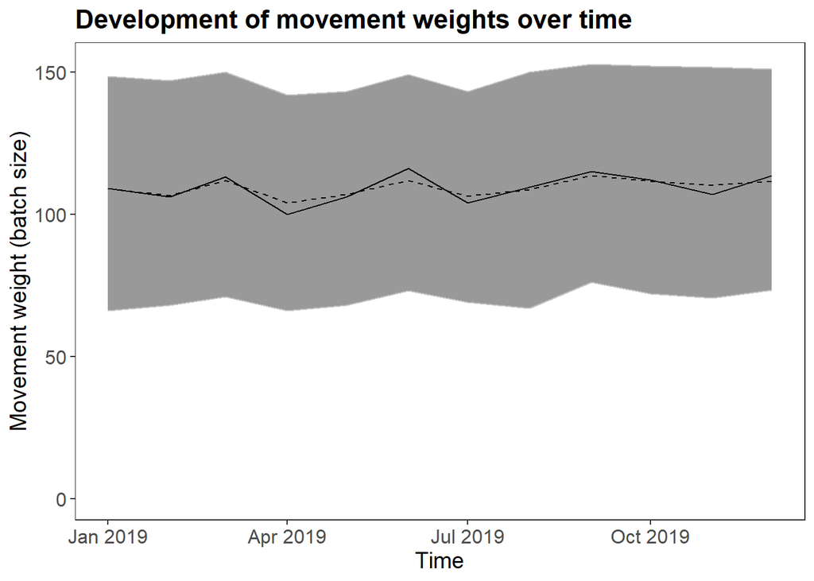

# Static network analysis (monthly snapshots)

## Component analysis

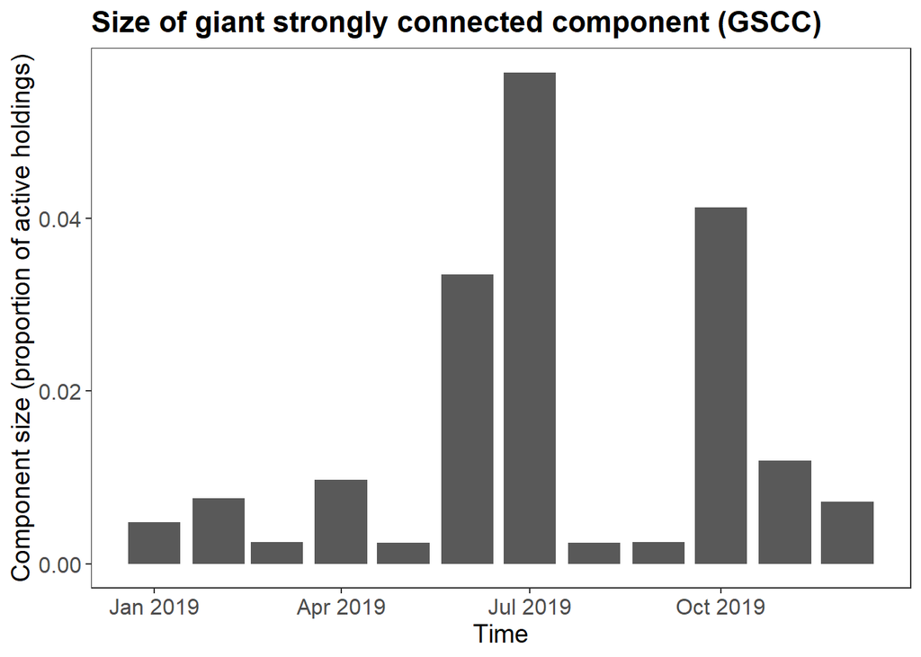

The largest giant strongly connected component (GSCC) is the largest number of nodes (holdings) that can all reach each other by some directed path of movements. This means that any node in that set could indirectly infect any other, or that a single source outbreak within the component could theoretically infect anything else within that component.

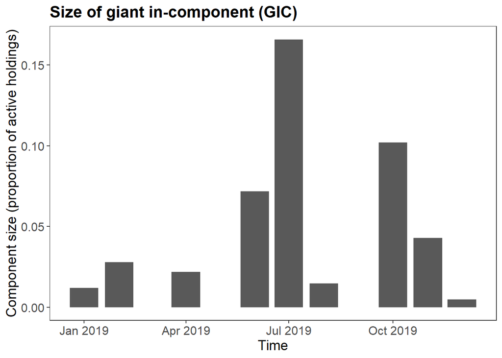

The giant in-component (GIC) consists of all nodes (holdings) that can reach the GSCC, but are not part of it, because there is no directed path from the GSCC to these nodes. This means that any holding in this set could infect holdings in the GSCC, but not be infected by them.

[figure not shown]

Conversely, the giant out-component (GOC) consists of all nodes (holdings) that can be reached from the GSCC, but are not part of it, because there is no directed path from these nodes to the GSCC. This means that any holding in this set could be infected by holdings in the GSCC, but not infect them.

## Loyalty

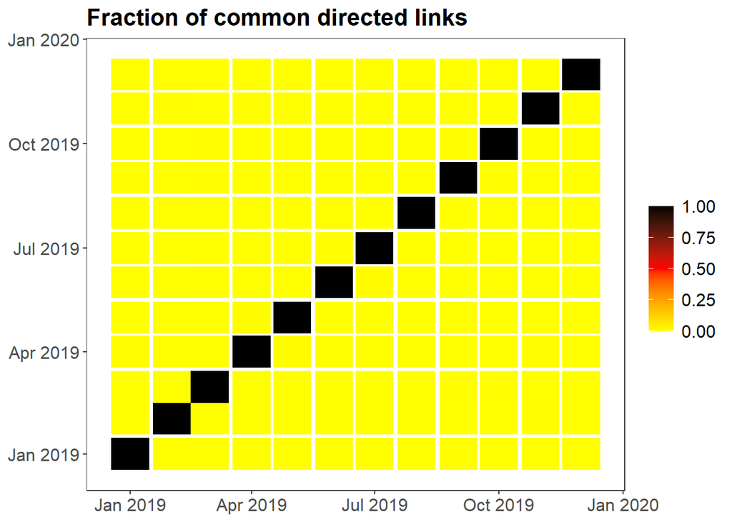

This is a measure of consistency in the network between different points in time. Darker colours indicate a larger proportion of trades that are in common between two months. The black diagonal indicates that each month’s movements are identical to themselves.

# Temporal network analysis

## Reachability (in- & out-going contact chains)

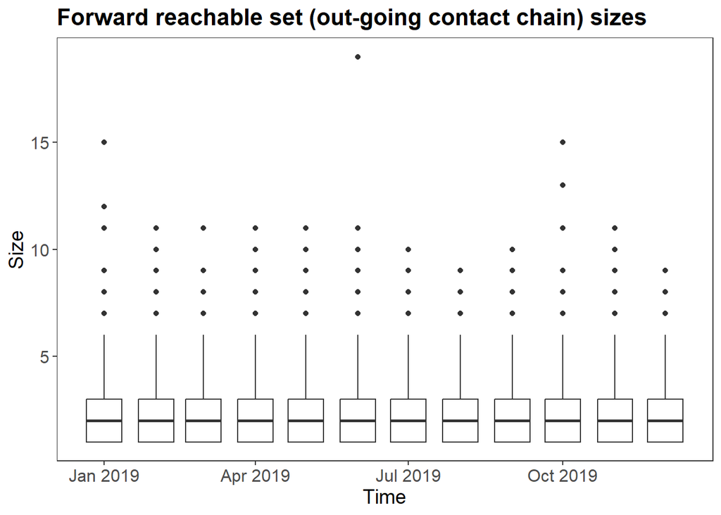

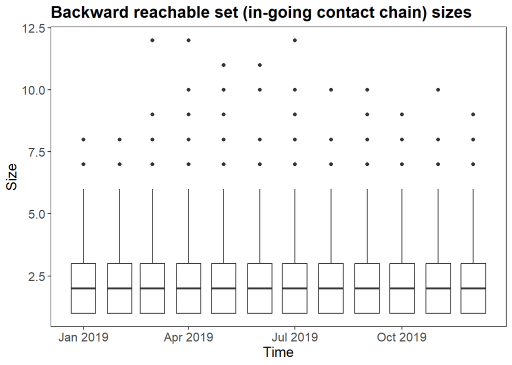

The forward reachable set (or out-going contact chain) of a single node is the set of nodes that can be reached from that origin node, or alternatively the set of nodes that could theoretically be infected in an outbreak starting at that node. That is, the set of nodes that are reachable from some origin node are the reachable set of that origin node. The backward reachable set (or in-going contact chain) is the set of nodes that reach a node.